# How Do Health, Ethics and Developer Kinship Correlate to Programmer Salary?

# 1. Business Understanding

This notebook seeks to understand how a programmer's earnings are related to his or her attentiveness to health, ethics and kinship.

## Motivating Questions

1. Do health conscious programmers make more money?
2. Will prioritizing ethical concerns in the workplace cost you?
3. Does competitiveness or comraderie correspond to higher earnings?

The hope is that answering these questions will shine light on non-programming related activites and behaviors that may, or may not, inform earnings or earning potential.

## Success Criteria

We will consider our exploration a success if we find satisfying answers to our motivating questions.

# 2. Data Understanding

Let's import the libraries we will need.

Numpy (http://www.numpy.org/): For data modeling

Pandas (https://pandas.pydata.org/): For data modeling and visualization

Matplotlib (https://matplotlib.org/): For data visualization

Seaborns (https://seaborn.pydata.org/): For data visualization

```python
import numpy as np
import pandas as pd
import matplotlib.pyplot as plt
import seaborn as sns

from IPython.display import display

# Filter warnings
import warnings
warnings.filterwarnings('ignore')

# Better display for notebooks
%matplotlib inline
```

### Gather StackOverflow Survey Data and Survey schema into dataframes

```python
# Read the survey results into a dataframe

results_df = pd.read_csv('.\developer_survey_2018\survey_results_public.csv')
```

```python
# Read the survey schema into a dataframe

schema_df = pd.read_csv('.\developer_survey_2018\survey_results_schema.csv')
```

### Explore the Data

How many people responded to the survey?

```python
print("Number of respondents: ", results_df.shape[0])
```

```
Number of respondents:  98855
```

How many questions were asked, and what is the type of attributes?

```python
# View general results survey df attributes

results_df.info()
```

```
<class 'pandas.core.frame.DataFrame'>
RangeIndex: 98855 entries, 0 to 98854
Columns: 129 entries, Respondent to SurveyEasy
dtypes: float64(41), int64(1), object(87)
memory usage: 97.3+ MB
```

Looks like a 129 questions were asked. And the responses are either floating points, integers, or objects

Let's view a few rows of the survey results.

```python
results_df.head()
```

|  | Respondent | Hobby | OpenSource | Country | Student | Employment | FormalEducation | UndergradMajor | CompanySize | DevType | ... | Exercise | Gender | SexualOrientation | EducationParents | RaceEthnicity | Age | Dependents | MilitaryUS | SurveyTooLong | SurveyEasy |
| --- | --- | --- | --- | --- | --- | --- | --- | --- | --- | --- | --- | --- | --- | --- | --- | --- | --- | --- | --- | --- | --- |
| 0 | 1 | Yes | No | Kenya | No | Employed part-time | Bachelor’s degree (BA, BS, B.Eng., etc.) | Mathematics or statistics | 20 to 99 employees | Full-stack developer | ... | 3 - 4 times per week | Male | Straight or heterosexual | Bachelor’s degree (BA, BS, B.Eng., etc.) | Black or of African descent | 25 - 34 years old | Yes | NaN | The survey was an appropriate length | Very easy |
| 1 | 3 | Yes | Yes | United Kingdom | No | Employed full-time | Bachelor’s degree (BA, BS, B.Eng., etc.) | A natural science (ex. biology, chemistry, phy... | 10,000 or more employees | Database administrator;DevOps specialist;Full-... | ... | Daily or almost every day | Male | Straight or heterosexual | Bachelor’s degree (BA, BS, B.Eng., etc.) | White or of European descent | 35 - 44 years old | Yes | NaN | The survey was an appropriate length | Somewhat easy |
| 2 | 4 | Yes | Yes | United States | No | Employed full-time | Associate degree | Computer science, computer engineering, or sof... | 20 to 99 employees | Engineering manager;Full-stack developer | ... | NaN | NaN | NaN | NaN | NaN | NaN | NaN | NaN | NaN | NaN |
| 3 | 5 | No | No | United States | No | Employed full-time | Bachelor’s degree (BA, BS, B.Eng., etc.) | Computer science, computer engineering, or sof... | 100 to 499 employees | Full-stack developer | ... | I don't typically exercise | Male | Straight or heterosexual | Some college/university study without earning ... | White or of European descent | 35 - 44 years old | No | No | The survey was an appropriate length | Somewhat easy |
| 4 | 7 | Yes | No | South Africa | Yes, part-time | Employed full-time | Some college/university study without earning ... | Computer science, computer engineering, or sof... | 10,000 or more employees | Data or business analyst;Desktop or enterprise... | ... | 3 - 4 times per week | Male | Straight or heterosexual | Some college/university study without earning ... | White or of European descent | 18 - 24 years old | Yes | NaN | The survey was an appropriate length | Somewhat easy |

5 rows × 129 columns

Let's view a few rows of the survey schema

```python
schema_df.head()
```

|  | Column | QuestionText |
| --- | --- | --- |
| 0 | Respondent | Randomized respondent ID number (not in order ... |
| 1 | Hobby | Do you code as a hobby? |
| 2 | OpenSource | Do you contribute to open source projects? |
| 3 | Country | In which country do you currently reside? |
| 4 | Student | Are you currently enrolled in a formal, degree... |

The schema will be helpful by providing us the exact question text and the column it aligns with in the results dataframe

Let's see which questions relate to income, health, ethics and kinship

```python
with pd.option_context('display.max_rows', None) :
      with pd.option_context('display.max_colwidth', 1000) :
        display(schema_df)
```

|  | Column | QuestionText |
| --- | --- | --- |
| 0 | Respondent | Randomized respondent ID number (not in order of survey response time) |
| 1 | Hobby | Do you code as a hobby? |
| 2 | OpenSource | Do you contribute to open source projects? |
| 3 | Country | In which country do you currently reside? |
| 4 | Student | Are you currently enrolled in a formal, degree-granting college or university program? |
| 5 | Employment | Which of the following best describes your current employment status? |
| 6 | FormalEducation | Which of the following best describes the highest level of formal education that you’ve completed? |
| 7 | UndergradMajor | You previously indicated that you went to a college or university. Which of the following best describes your main field of study (aka 'major') |
| 8 | CompanySize | Approximately how many people are employed by the company or organization you work for? |
| 9 | DevType | Which of the following describe you? Please select all that apply. |
| 10 | YearsCoding | Including any education, for how many years have you been coding? |
| 11 | YearsCodingProf | For how many years have you coded professionally (as a part of your work)? |
| 12 | JobSatisfaction | How satisfied are you with your current job? If you work more than one job, please answer regarding the one you spend the most hours on. |
| 13 | CareerSatisfaction | Overall, how satisfied are you with your career thus far? |
| 14 | HopeFiveYears | Which of the following best describes what you hope to be doing in five years? |
| 15 | JobSearchStatus | Which of the following best describes your current job-seeking status? |
| 16 | LastNewJob | When was the last time that you took a job with a new employer? |
| 17 | AssessJob1 | Imagine that you are assessing a potential job opportunity. Please rank the following aspects of the job opportunity in order of importance (by dragging the choices up and down), where 1 is the most i… |
| 18 | AssessJob2 | Imagine that you are assessing a potential job opportunity. Please rank the following aspects of the job opportunity in order of importance (by dragging the choices up and down), where 1 is the most i… |
| 19 | AssessJob3 | Imagine that you are assessing a potential job opportunity. Please rank the following aspects of the job opportunity in order of importance (by dragging the choices up and down), where 1 is the most i… |
| 20 | AssessJob4 | Imagine that you are assessing a potential job opportunity. Please rank the following aspects of the job opportunity in order of importance (by dragging the choices up and down), where 1 is the most i… |
| 21 | AssessJob5 | Imagine that you are assessing a potential job opportunity. Please rank the following aspects of the job opportunity in order of importance (by dragging the choices up and down), where 1 is the most i… |
| 22 | AssessJob6 | Imagine that you are assessing a potential job opportunity. Please rank the following aspects of the job opportunity in order of importance (by dragging the choices up and down), where 1 is the most i… |
| 23 | AssessJob7 | Imagine that you are assessing a potential job opportunity. Please rank the following aspects of the job opportunity in order of importance (by dragging the choices up and down), where 1 is the most i… |
| 24 | AssessJob8 | Imagine that you are assessing a potential job opportunity. Please rank the following aspects of the job opportunity in order of importance (by dragging the choices up and down), where 1 is the most i… |
| 25 | AssessJob9 | Imagine that you are assessing a potential job opportunity. Please rank the following aspects of the job opportunity in order of importance (by dragging the choices up and down), where 1 is the most i… |
| 26 | AssessJob10 | Imagine that you are assessing a potential job opportunity. Please rank the following aspects of the job opportunity in order of importance (by dragging the choices up and down), where 1 is the most i… |
| 27 | AssessBenefits1 | Now, imagine you are assessing a job's benefits package. Please rank the following aspects of a job's benefits package from most to least important to you (by dragging the choices up and down), where … |
| 28 | AssessBenefits2 | Now, imagine you are assessing a job's benefits package. Please rank the following aspects of a job's benefits package from most to least important to you (by dragging the choices up and down), where … |
| 29 | AssessBenefits3 | Now, imagine you are assessing a job's benefits package. Please rank the following aspects of a job's benefits package from most to least important to you (by dragging the choices up and down), where … |

[output cut: 99 more lines]

### Survey Responses that will Help Answer our Questions

**Income-Related Questions**

1. ConvertedSalary - Salary converted to annual USD salaries using the exchange rate on 2018-01-18, assuming 12 working months and 50 working weeks.

**Variables We'd Like To Control For**

**Health-Related Questions**

1. Exercise -> In a typical week, how many times do you exercise?
2. SkipMeals -> In a typical week, how many times do you skip a meal in order to be more productive?
3. ErgonomicDevices -> What ergonomic furniture or devices do you use on a regular basis? Please select all that apply.

**Ethics-Related Questions**

1. EthicsChoice -> Do you report or otherwise call out the unethical code in question?
2. EthicsReport -> Do you report or otherwise call out the unethical code in question?
3. EthicalImplications -> Do you believe that you have an obligation to consider the ethical implications of the code that you write?

**Kinship-Related Questions**

1. AgreeDisagree1 -> To what extent do you agree or disagree with each of the following statements? I feel a sense of kinship or connection to other developers
2. AgreeDisagree2 -> To what extent do you agree or disagree with each of the following statements? I think of myself as competing with my peers

### Let's Check the Data Types, Number of Missing Values, and Unique Values and Counts for Each Variable of Interest

```python
response_vars = ['ConvertedSalary', 'Employment', 'YearsCoding', 'FormalEducation', 'Exercise', 'SkipMeals', 'ErgonomicDevices', 'EthicsChoice', \
                 'EthicsReport', 'EthicalImplications', 'AgreeDisagree1', 'AgreeDisagree2']
```

```python
for rv in response_vars :

    print('\n', rv, '\n\tData Type = ', results_df[rv].dtype)
    print('\tNumber of Missing Values =', results_df[rv].isnull().sum())
    if (rv != 'ConvertedSalary') :
        print('\tValue Counts')
        for index, item in results_df[rv].value_counts().iteritems() :
            print('\t\t', index, ': ', item)
```

```
 ConvertedSalary
	Data Type =  float64
	Number of Missing Values = 51153

 Employment
	Data Type =  object
	Number of Missing Values = 3534
	Value Counts
		 Employed full-time :  70495
		 Independent contractor, freelancer, or self-employed :  9282
		 Not employed, but looking for work :  5805
		 Employed part-time :  5380
		 Not employed, and not looking for work :  4132
		 Retired :  227

 YearsCoding
	Data Type =  object
	Number of Missing Values = 5020
	Value Counts
		 3-5 years :  23313
		 6-8 years :  19338
		 9-11 years :  12169
		 0-2 years :  10682
		 12-14 years :  8030
		 15-17 years :  6117
		 18-20 years :  5072
		 30 or more years :  3544
		 21-23 years :  2648
		 24-26 years :  1862
		 27-29 years :  1060

 FormalEducation
	Data Type =  object
	Number of Missing Values = 4152
	Value Counts
		 Bachelor’s degree (BA, BS, B.Eng., etc.) :  43659
		 Master’s degree (MA, MS, M.Eng., MBA, etc.) :  21396
		 Some college/university study without earning a degree :  11710
		 Secondary school (e.g. American high school, German Realschule or Gymnasium, etc.) :  8951
		 Associate degree :  2970
```

[output cut: 72 more lines]

```
		 Agree :  36777
		 Neither Agree nor Disagree :  14676
		 Strongly agree :  11332
		 Disagree :  3941
		 Strongly disagree :  1491

 AgreeDisagree2
	Data Type =  object
	Number of Missing Values = 30509
	Value Counts
		 Agree :  18673
		 Neither Agree nor Disagree :  17995
		 Disagree :  17523
		 Strongly disagree :  8826
		 Strongly agree :  5329
```

Let's view some statistics about the salary

```python
results_df[response_vars].describe()
```

|  | ConvertedSalary |
| --- | --- |
| count | 4.770200e+04 |
| mean | 9.578086e+04 |
| std | 2.023482e+05 |
| min | 0.000000e+00 |
| 25% | 2.384400e+04 |
| 50% | 5.507500e+04 |
| 75% | 9.300000e+04 |
| max | 2.000000e+06 |

# 3. Data Preparation: Cleaning and Deriving New Features

## Drop Rows Missing Salary

Since our motivating questions rely on knowing the respondent's salary, we have to drop rows that don't have this information

Drop rows missing salary and with salary of 0 - presumably students and job hunters

```python
results_df = results_df.dropna(subset=['ConvertedSalary'])
results_df = results_df[results_df.ConvertedSalary != 0]

# How many respondents remain

print("Number of remaining respondents: ", results_df.shape[0])
```

```
Number of remaining respondents:  46860
```

## Implement Controls

To make sure we're controlling for as many variables unrelated to health, ethics and kinship as possible, we need to group our respondents into cohorts that remove as many other factors as possible.

Based on the response questions, it seems reasonable to group based on employment status, years employed (since the longer you've worked the more you are likely to make), and education degree (since this could impact earnings).

### Control for Employment Status

Only keep respondents employed full-time for fair comparison. Otherwise, we will be comparing the salaries of students, retirees, part-time workers, freelancers, etc. to those working consistently, which could skew our findings.

```python
results_df = results_df[results_df.Employment == 'Employed full-time']
print('Number of remaining respondents: ', results_df.shape[0])
```

```
Number of remaining respondents:  39266
```

### Control for Years Coding Professionally

First let's drop anyone who did not respond to the coding professionally question. We have to do this since we are going to be grouping our respondents based on the number of years they have spent coding. Creating a dummy "no_response" variable will not be a reliable grouping method since it could contain programmers with highly varying years of experience.

```python
results_df = results_df.dropna(subset = ['YearsCodingProf'])
```

```python
results_df.YearsCodingProf.value_counts()
```

```
3-5 years           11524
0-2 years            8615
6-8 years            6587
9-11 years           4521
12-14 years          2479
15-17 years          1721
18-20 years          1622
21-23 years           744
30 or more years      559
24-26 years           444
27-29 years           268
Name: YearsCodingProf, dtype: int64
```

Let's create three groups for years coding professionally: <= 5 years, 6 - 11 years, > 11 years

```python
results_df['CodingProfessionally'] = results_df.YearsCodingProf.apply(lambda y : '<= 5 years' if (y == '0-2 years' or y == '3-5 years') \
                                                                 else '5 - 10 years' if (y == '6-8 years' or y == '9-11 years') else \
                                                                 '> 11 years')
```

```python
results_df.CodingProfessionally.value_counts()
```

```
<= 5 years      20139
5 - 10 years    11108
> 11 years       7837
Name: CodingProfessionally, dtype: int64
```

### Control for Education Degree

In an attempt to isolate the influence of health, ethics and kinship, we will compare respondees based on similar levels of educational attainment.

First let's drop anyone who did not respond to the formal education question since this will be another factor we control for. Again, we don't want to make a dummy variable for the non-responses since it could contain a lot of educational variation from which it would be hard to draw conclusions.

```python
results_df = results_df.dropna(subset = ['FormalEducation'])
print('Number of remaining respondents: ', results_df.shape[0])
```

```
Number of remaining respondents:  38570
```

Create an EducationDegree category consisting of either: Below Bachelor, Bachelor and Above Bachelor

```python
results_df['EducationDegree'] = results_df.FormalEducation.astype(str).apply(lambda val : 'Bach' if 'Bachelor' in val \
                                                                           else 'Above Bach' if (('Master' in val) or ('Professional' in val) or ('doctoral' in val)) \
                                                                           else 'Below Bach')
```

```python
results_df.EducationDegree.value_counts()
```

```
Bach          19736
Above Bach    11177
Below Bach     7657
Name: EducationDegree, dtype: int64
```

Let's focus on respondents with bachelor degrees or higher for two reasons:

1. They have the highest number of responses
2. Below bachelors degree contains a lot of variability in terms of education attainment (no high school, secondary school, associate's degree, etc) and so it is too noisy.

```python
# Drop the below bachelor rows

results_df = results_df[results_df.EducationDegree != 'Below Bach']
results_df.EducationDegree.value_counts()
```

```
Bach          19736
Above Bach    11177
Name: EducationDegree, dtype: int64
```

## Check sample size per cohort

Since we will have six overall cohorts, let's see if we have enough samples to yield us statistically significant inforation

```python
results_df.groupby(['EducationDegree', 'CodingProfessionally']).Respondent.count()
```

```
EducationDegree  CodingProfessionally
Above Bach       5 - 10 years             3615
                 <= 5 years               5087
                 > 11 years               2475
Bach             5 - 10 years             5363
                 <= 5 years              10941
                 > 11 years               3432
Name: Respondent, dtype: int64
```

## Clean and Derive New Health-Conciousness Features

```python
# Let's create a health_df dataframe for to use in our health-related analysis
health_df = results_df.copy()
```

Let's take a look at the variables related to 'health-consciousness'

### Clean Health-Related Question 1: Exercise

Let's map the exercise answers to shorter ones for better display down the line

```python
health_df['Exercise'] = health_df.Exercise.map({"I don't typically exercise" : 'Rarely',
                                                    '1 - 2 times per week' : '1-2 wkly',
                                                    '3 - 4 times per week' : '3-4 wkly',
                                                    'Daily or almost every day': 'Daily'})
```

```python
health_df.Exercise.value_counts(dropna=False)
```

```
Rarely      10486
1-2 wkly     8954
3-4 wkly     6378
Daily        4032
NaN          1063
Name: Exercise, dtype: int64
```

### Create exercise score for later use in a combined 'Health Score'

Since we want an overall measure of a person's health-consciouness, let's eventually combine the responses to the individual questions into an overall health score. To do this, we need to transform the answers to the exercise questions into a numeric measure of healthiness, with zero being the least healthy and 3 being the most.

```python
health_df['ExerciseScore'] = health_df.Exercise.map({'Rarely' : 0,
                                                    '1-2 wkly' : 1,
                                                    '3-4 wkly' : 2,
                                                    'Daily': 3})

health_df.ExerciseScore.value_counts()
```

```
0.0    10486
1.0     8954
2.0     6378
3.0     4032
Name: ExerciseScore, dtype: int64
```

### Clean Health-Related Question 2: Skipped Meals

Let's map the values skipped meal answers to shorter ones for better display down the line

```python
health_df['SkipMeals'] = health_df.SkipMeals.map({'Never' : 'Never',
                                                    '1 - 2 times per week' : '1-2 wkly',
                                                    '3 - 4 times per week' : '3-4 wkly',
                                                    'Daily or almost every day': 'Daily'})
```

### Create Meals Score where the less meals skipped gives you higher score for use in overall health score

```python
health_df['Meals_Score'] = health_df.SkipMeals.apply(lambda val : 3 if val == 'Never' else 2 if val == '1-2 wkly' else 1 if val == '3-4 wkly' else  0)
health_df.Meals_Score.value_counts()
```

```
3    20768
2     6578
0     2246
1     1321
Name: Meals_Score, dtype: int64
```

### Clean and Derive New Category for Health-Related Question 3: Ergonomic Devices

Since ErgnomicDevices doesn't have an option for none, replace NaN with 'None'

```python
health_df.ErgonomicDevices.fillna('None', inplace=True)
```

Create a column called 'NumErgonomics' which contains number of ergonomic devices used

```python
health_df['NumErgonomics'] = health_df.ErgonomicDevices.apply(lambda val : 0 if val == 'None' else (1 + val.count(';')))

health_df.NumErgonomics.value_counts()
```

```
0    16505
1     9932
2     3408
3      884
4      184
Name: NumErgonomics, dtype: int64
```

Collapse 3 and 4 into '3' to align with other variables health score. This will ensure each question contributes an equal amount to the overall health score.

```python
health_df['NumErgonomics'][health_df.NumErgonomics == 4] = 3
health_df.NumErgonomics.value_counts()
```

```
0    16505
1     9932
2     3408
3     1068
Name: NumErgonomics, dtype: int64
```

### Create New Dataframe and Derive Health Score

Create a new health-score dataframe by dropping any rows that don't have answers for all three of our health-related questions. This is to ensure that our health score is weighted evenly per respondent.

```python
# First drop all rows with missing values
health_score_df = health_df.dropna(subset=['ErgonomicDevices','Exercise','SkipMeals'])

print('Number of respondents for overall health score: ', health_score_df.shape[0])
```

```
Number of respondents for overall health score:  29766
```

Create a "Health_Score" column that is the sum of all the invididual health scores

```python
health_score_df['Health_Score']=health_score_df.apply(lambda row: row['NumErgonomics'] + row['ExerciseScore'] + row['Meals_Score'], axis=1)
```

## Clean and Derive Ethics-Related Features

```python
ethics_df = results_df.copy()
```

### Create a column called Ethical_Choice_Score with 2 being highest ethics and 0 the lowest

Analogous to our Health Score, we will have an ethics score that ranks the overall "ethic-mindedness" of a given respondent

```python
ethics_df['Ethical_Choice_Score'] = ethics_df.EthicsChoice.apply(lambda val : 2 if val == 'No' else 0 if val == 'Yes' else 1)
ethics_df.Ethical_Choice_Score.value_counts()
```

```
2    18227
1    11590
0     1096
Name: Ethical_Choice_Score, dtype: int64
```

### Clean the "Report Unethical Code Question"

```python
ethics_df.EthicsReport.value_counts()
```

```
Depends on what it is               13217
Yes, but only within the company    11869
Yes, and publicly                    3533
No                                   1030
Name: EthicsReport, dtype: int64
```

Let's collapse the yes's and shorten the 'depends' answer

```python
ethics_df['EthicsReport'] = ethics_df.EthicsReport.map({'Yes, but only within the company' : 'Yes',
                                          'Yes, and publicly' : 'Yes',
                                          'No' : 'No',
                                          'Depends on what it is' : 'Depends'})

ethics_df.EthicsReport.value_counts()
```

```
Yes        15402
Depends    13217
No          1030
Name: EthicsReport, dtype: int64
```

Create a colum called Ethical_Report_Score with 2 being the highest ethics and 0 the lowest for later use in a combined ethics score

```python
ethics_df['Ethical_Report_Score'] = ethics_df.EthicsReport.apply(lambda val : 0 if val == 'No' else 2 if val == 'Yes' else 1)
ethics_df.Ethical_Report_Score.value_counts()
```

```
2    15402
1    14481
0     1030
Name: Ethical_Report_Score, dtype: int64
```

Create a colum called Ethical_Implications_Score with 2 being the highest ethics and 0 the lowest for use in the combined ethics score

```python
ethics_df['Ethical_Implications_Score'] = ethics_df.EthicalImplications.apply(lambda val : 0 if val == 'No' else 2 if val == 'Yes' else 1)
ethics_df.Ethical_Implications_Score.value_counts()
```

```
2    24404
1     5003
0     1506
Name: Ethical_Implications_Score, dtype: int64
```

### Create a new dataframe that will have a total 'Ethics Score' score by adding together the individual scores

First drop all rows with any missing values for the three ethics questions for the same reason we did so with the health score.

```python
ethics_score_df = ethics_df.dropna(subset=['EthicalImplications','EthicsReport','EthicsChoice'])
```

Create a total ethics store by adding together the individual scores

```python
ethics_score_df['Ethics_Score']=ethics_score_df.apply(lambda row: row['Ethical_Implications_Score'] + row['Ethical_Report_Score'] + row['Ethical_Choice_Score'], axis=1)
```

## Clean and Derive Kinship-Related Features

### Clean Kinship Question

```python
kinship_df = results_df.copy()
```

```python
kinship_df.AgreeDisagree1.value_counts()
```

```
Agree                         17006
Neither Agree nor Disagree     5794
Strongly agree                 5153
Disagree                       1657
Strongly disagree               486
Name: AgreeDisagree1, dtype: int64
```

Let's map these to numeric values from lowest to highest sense of kinship

```python
kinship_df['Feel_Developer_Kinship'] =kinship_df.AgreeDisagree1.map({'Strongly agree' : 4,
                                                                   'Agree' : 3,
                                                                   'Neither Agree nor Disagree' : 2,
                                                                   'Disagree' : 1,
                                                                   'Strongly disagree' : 0})

kinship_df.Feel_Developer_Kinship.value_counts()
```

```
3.0    17006
2.0     5794
4.0     5153
1.0     1657
0.0      486
Name: Feel_Developer_Kinship, dtype: int64
```

### Clean Competition Question

```python
kinship_df.AgreeDisagree2.value_counts()
```

```
Disagree                      8312
Agree                         8264
Neither Agree nor Disagree    7462
Strongly disagree             3940
Strongly agree                2150
Name: AgreeDisagree2, dtype: int64
```

Let's map these to numeric values with representing amount of competitiveness felt

```python
kinship_df['Compete_With_Developers'] =kinship_df.AgreeDisagree2.map({'Strongly agree' : 4,
                                                                   'Agree' : 3,
                                                                   'Neither Agree nor Disagree' : 2,
                                                                   'Disagree' : 1,
                                                                   'Strongly disagree' : 0})

kinship_df.Compete_With_Developers.value_counts()
```

```
1.0    8312
3.0    8264
2.0    7462
0.0    3940
4.0    2150
Name: Compete_With_Developers, dtype: int64
```

### Derive Overall Kinship Felt Score and Salary

Create a new kinship dataframe by dropping any row missing an answer to our kinship questions

```python
kinship_score_df = kinship_df.dropna(subset=['AgreeDisagree1','AgreeDisagree2'])
```

```python
kinship_score_df['Kinship_Score']=kinship_score_df.apply(lambda row: row['Feel_Developer_Kinship'] - row['Compete_With_Developers'] , axis=1)
```

# 4. Visualization and Evaluation

Now that our data is clean and we have all the features we need, it's time to visualize the relationship between health, ethics and kinship and earning.

First, let's set our matplotlib defaults

```python
plt.rcParams['figure.titlesize'] = 24
plt.rcParams['axes.labelsize'] = 16
plt.rcParams['xtick.labelsize'] = 14
plt.rcParams['ytick.labelsize'] = 14
plt.rcParams['figure.autolayout'] = True
```

Since we will be creating a number of visuals, let's define a re-usable function that will make the same chart for our different variables.

```python
def salary_factor_charts(x_var, x_label, mean_or_median, df, add_regression = False) :

    """
    Creates factor chart that plots a variable against salary

    The factor charts will use EducationDegree control as the columnns and the CodingProfesionally control as the rows.

    Parameters:
    x_var (string): Name of the variable to plot against salary while control for Education and Years Coding professionally

    x_label (string): Label for the X axis

    mean_or_median (string) : String that must be 'mean' or 'median' that determines the estimator function to use

    df (string): Name of the dataframe containing the data to chart

    add_regression (boolean) : Determine whether or not to overlay a regression line.
    Returns: Nothing

    """

    if (mean_or_median == 'Mean') :
        estimator_func = np.mean
    elif (mean_or_median == 'Median') :
        estimator_func = np.median
    else :
        print ('Please enter either "Mean" or "Median" for the third argument')
        return None

    g = sns.factorplot(x=x_var, y='ConvertedSalary', col='EducationDegree', row='CodingProfessionally', data=df, sharex=False, sharey=False, aspect=1.75, kind='bar', legend=False, estimator=estimator_func)

    if (add_regression) :
        g = g.map(sns.regplot, x_var, 'ConvertedSalary', scatter=False, fit_reg=True)

    for ax in g.axes.flat :
        ax.set_ylabel(mean_or_median +' Salary (USD)')
        ax.set_xlabel(x_label)

    return None
```

### Visualize / Evaluate the relationship between exercise and salary

Does exercise correlate with salaries regardless of our education degree and years coding professionally cohorts?

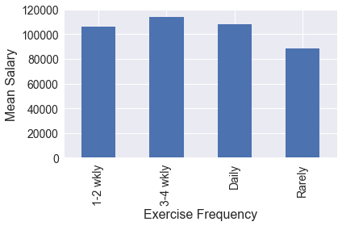

```python
ax = health_df.groupby('Exercise').mean().ConvertedSalary.plot(kind='bar')
ax.set_ylabel('Mean Salary')
ax.set_xlabel('Exercise Frequency')
```

It looks like those who exercise do make more than those who rarely do. However, we can see that more exercise doesn't trend directly with higher incomes.

Let's see how the mean salary relates to exercise when controlling for education degree and years coding

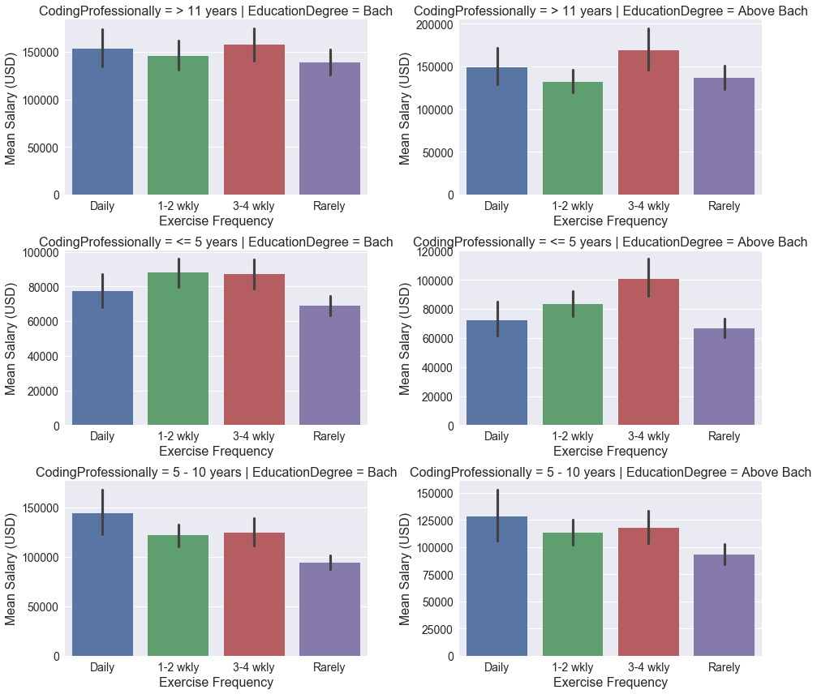

```python
salary_factor_charts('Exercise', 'Exercise Frequency', 'Mean', health_df)
```

In general, more exercise does equate to average higher salaries. The one exception is in the "> 11 Years Coding / Above Bachelor's" cohort where we see those who exercise rarely make more on average than those who exercise once or twice weekly.

Let's see how the median salary relates to exercise when controlling for education degree and years coding

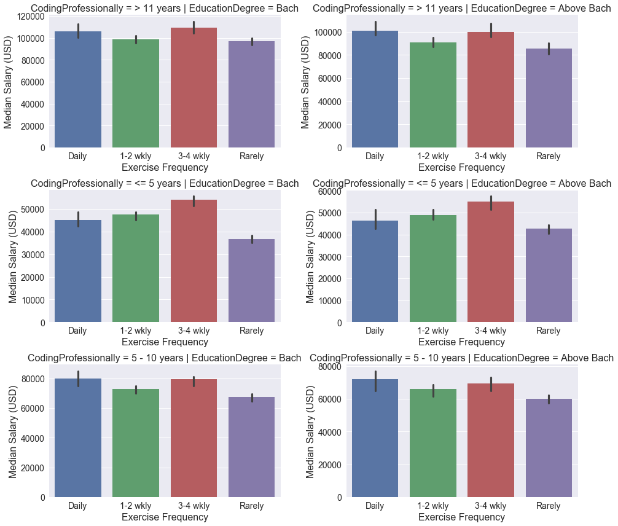

```python
salary_factor_charts('Exercise', 'Exercise Frequency', 'Median', health_df)
```

Using the median as our measure, we see that in every cohort those who exercise have a higher median income than those who rarely do, although for some frequencies in certain cohorts the difference is slight.

### Visualize / Evaluate the relationship between number of skipped meals and salary

Does number of meals skipped correlate with salaries regardless of cohort?

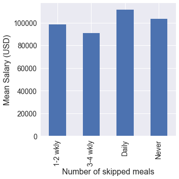

```python
ax = health_df.groupby('SkipMeals').mean().ConvertedSalary.plot(kind='bar', figsize=(5,5))
ax.set_ylabel('Mean Salary (USD)')
ax.set_xlabel('Number of skipped meals')
```

When measured without regard to cohort, our findings are inconclusive. Those who never skip meals have a higher average salary than those who skip every once and awhile. However, those who never skip make less on average than those skip meals daily.

Let's see how the mean salary relates to number of skipped meals when controlling for education degree and years coding

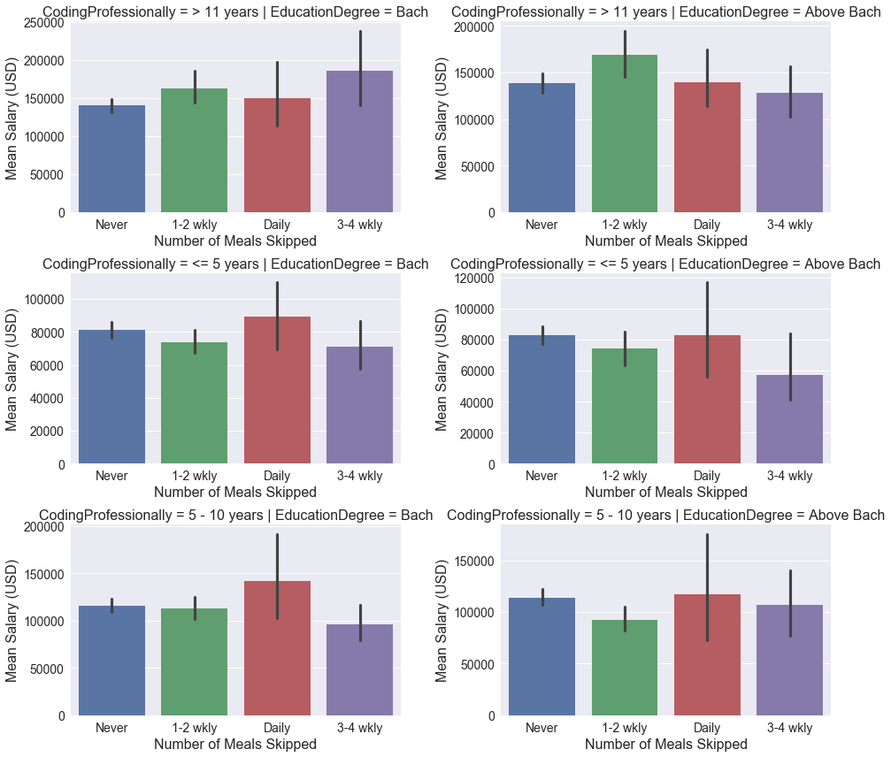

```python
salary_factor_charts('SkipMeals', 'Number of Meals Skipped', 'Mean', health_df)
```

Evaluated per cohort, our findings are still inconclusive when measured against mean salaries.

Let's see how the median salary relates to number of skipped meals when controlling for education degree and years coding

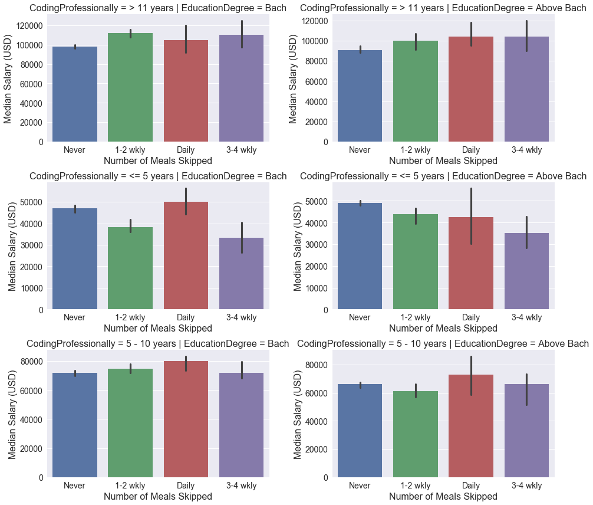

```python
salary_factor_charts('SkipMeals', 'Number of Meals Skipped', 'Median', health_df)
```

### Visualize / Evaluate the relationship between number of ergonomic devices used and salary

Does use of ergonomic devices correlate with mean salary regardless of cohort?

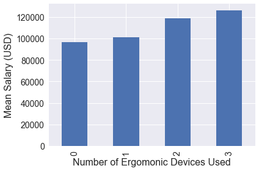

```python
ax = health_df.groupby('NumErgonomics').mean().ConvertedSalary.plot(kind='bar')
ax.set_ylabel('Mean Salary (USD)')
ax.set_xlabel('Number of Ergomonic Devices Used')
```

It looks like the more ergonomic devices used the more people make on average.

Does use of ergonomic devices correlate with median salaries regardless of cohort?

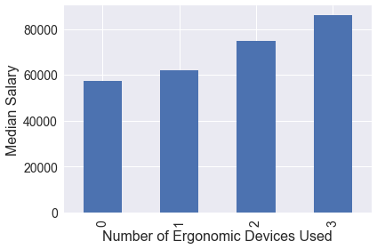

```python
ax = health_df.groupby('NumErgonomics').median().ConvertedSalary.plot(kind='bar')
ax.set_ylabel('Median Salary')
ax.set_xlabel('Number of Ergonomic Devices Used')
```

Same findings when measured against the median!

Let's see how the mean salary relates to ergonomic device use when controlling for education degree and years coding

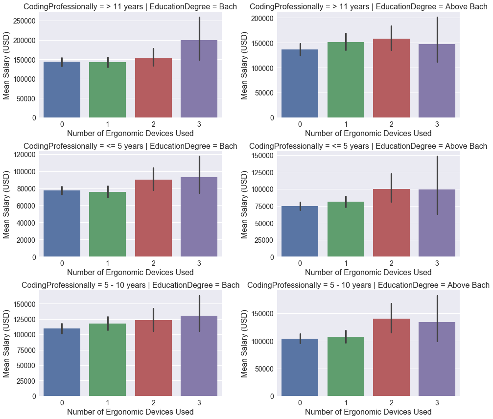

```python
salary_factor_charts('NumErgonomics', 'Number of Ergonomic Devices Used', 'Mean', health_df)
```

Let's see how the median salary relates to ergonomic device use when controlling for education degree and years coding

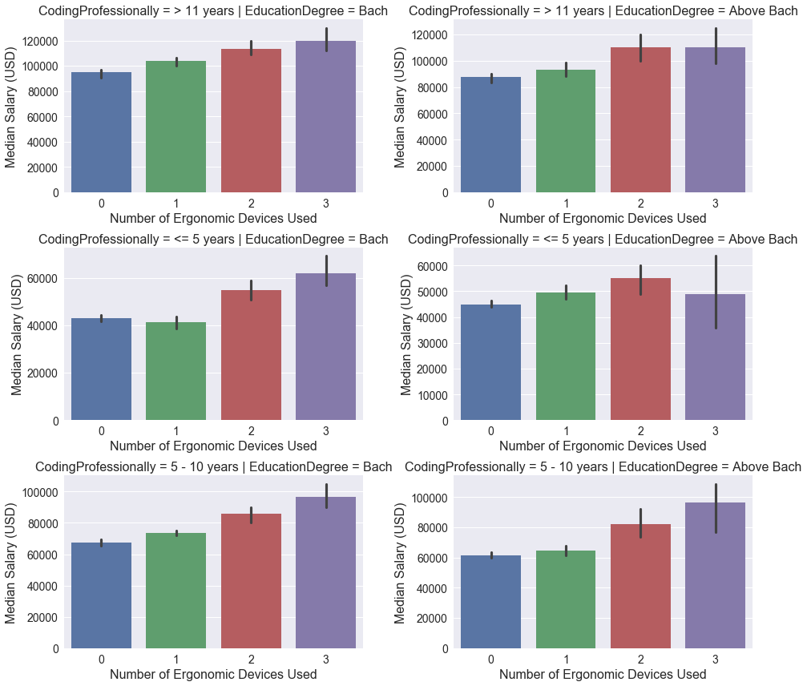

```python
salary_factor_charts('NumErgonomics', 'Number of Ergonomic Devices Used', 'Median', health_df)
```

For both the mean and median, more ergonomic devices correlates with more earnings.

### Visualize the Health-Score's Correlation with Salary

Check mean salaries against the health score without regard to education and years coding professionally

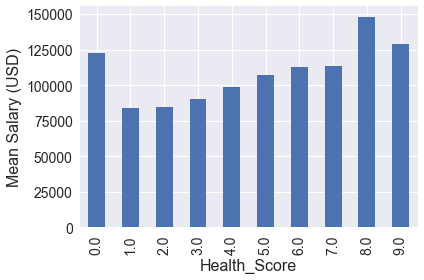

```python
ax = health_score_df.groupby('Health_Score').mean().ConvertedSalary.plot(kind='bar')
ax.set_ylabel('Mean Salary (USD)')
```

[figure not shown]

```python
ax = health_score_df.groupby('Health_Score').median().ConvertedSalary.plot(kind='bar')
ax.set_ylabel('Mean Salary (USD)')
```

Considered without regard to cohort, it looks like our health score does not trend directly with the means, although we do see the very healthy (8 and 9) make more on average than everyone less health.

When measured against the median, however, we see that people with health scores of 5 and above make more than everyone less healthy. This may indicate there are some outlier salaries in our cohorts that are skewing the averages.

Visualize the health scores relationship to salary across cohorts with a regression line

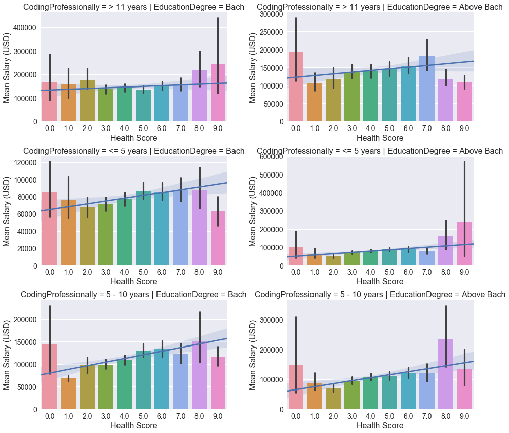

```python
salary_factor_charts('Health_Score', 'Health Score', 'Mean', health_score_df, True)
```

Based on our regression line, it looks like salaries do trend upward with overall health-consciousness.

# Visualize and Evaluate Ethics Relationship to Salary

```python
ethics_df = results_df.copy()
```

### Visualize the relationship between willingness to write unethical code and salary

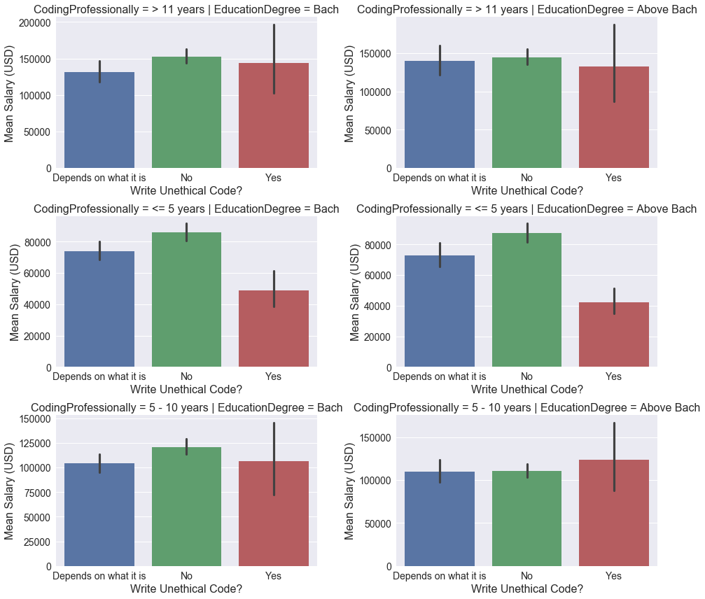

```python
salary_factor_charts('EthicsChoice', 'Write Unethical Code?', 'Mean', ethics_df)
```

### Visualize the Relationship between the "Report Unethical Code Question" and Salary

[figure not shown]

```python
salary_factor_charts('EthicsReport', 'Report Unethical Code?', 'Mean', ethics_df)
```

### Visualize the Relationship b/w Considering the Ethical Implications of your Code and Salary

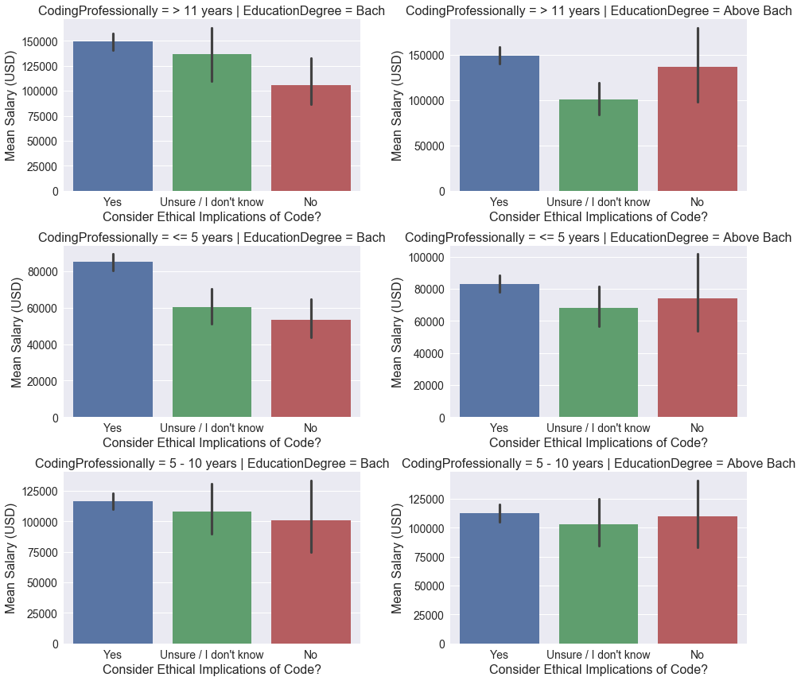

```python
salary_factor_charts('EthicalImplications', 'Consider Ethical Implications of Code?', 'Mean', ethics_df)
```

### Visualize how ethics relates to salary and plot a regression line

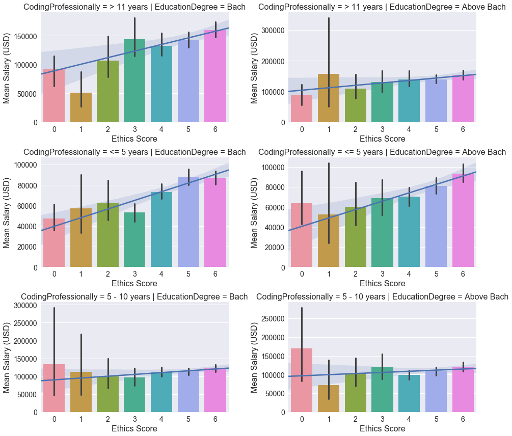

```python
salary_factor_charts('Ethics_Score', 'Ethics Score', 'Mean', ethics_score_df, True)
```

A programmer's sense of ethical obligations correlation to salary seems to vary significantly per cohort and question. Considered as an overall sense of ethics, however, it appears that a higher sense of ethical obligation does trend upward with salary.

### Visualize how a sense of kinship correlates to salary

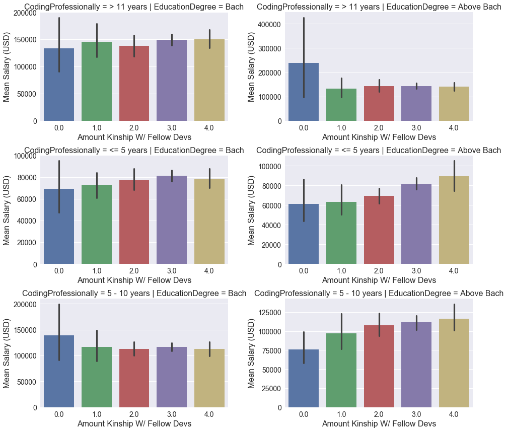

```python
salary_factor_charts('Feel_Developer_Kinship', 'Amount Kinship W/ Fellow Devs', 'Mean', kinship_df)
```

## Kinship Question 2: Do you feel a sense of competition with fellow programmers?

### Visualize the Relationship b/w Competition and Salary

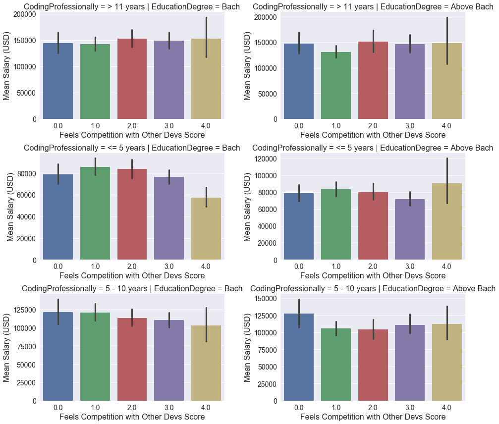

```python
salary_factor_charts('Compete_With_Developers', 'Feels Competition with Other Devs Score', 'Mean', kinship_df)
```

### Visualize how kinship relates to salary and plot a regression line

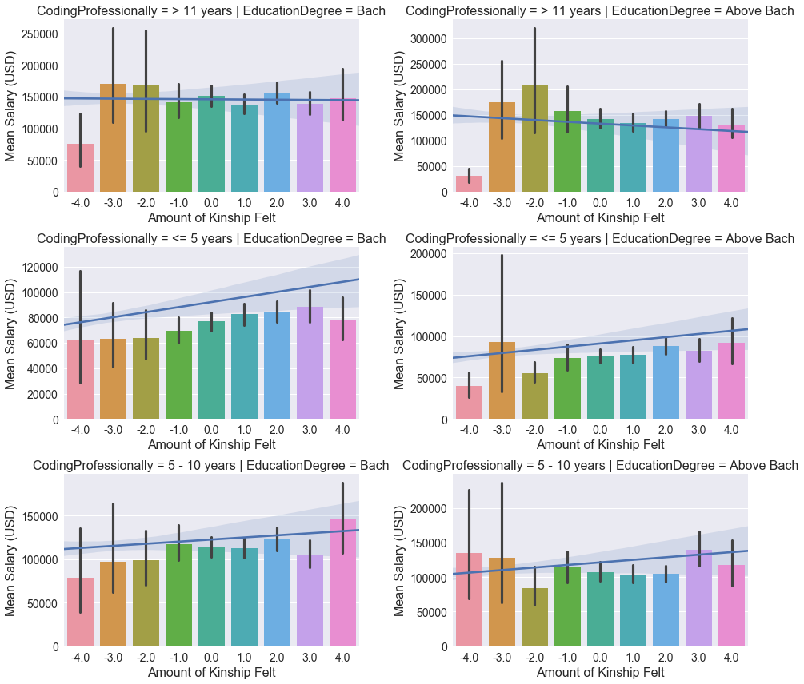

```python
salary_factor_charts('Kinship_Score', 'Amount of Kinship Felt', 'Mean', kinship_score_df, True)
```

It looks like for programmer’s with less than 11 years of professional coding experience, a sense of kinship correlates to slightly higher salaries. However, for those with more than 11 years of professional coding experience, those who feel less kinship earn more.

## Conclusions and Final Thoughts

It’s worth pointing out that correlation is not causation! For example, the above graphs do not indicate that leading a healthy lifestyle causes higher earnings. It’s possible that those with higher earnings have more resources to lead health lifestyles. Similarly, maybe the richer among us have the luxury of considering the ethical implications of their code while those who are earn less don’t.

What we can conclude, however, is that attending to one’s health and ethics does not seem to cost you, and may even benefit a programmer’s bottom line.

When it comes to kinship, it seems that as we gain in professional experience, earnings accrue more to the competitors than to the collaborators.